# Solar module I-V

The parameters of a solar panel are given in the table below.

| Parameter | Value |
| --- | --- |
| $P_{max}$ (W) | 320 |
| Voltage at $P_{max}$ (V) | 33.4 |
| Current at $P_{max}$ (A) | 9.59 |
| $V_{OC}$ at STC (V) | 40.9 |
| $I_{SC}$ at STC (A) | 10.15 |
| Temperature coefficient for $I_{SC}$ ($\%/^oC$) | 0.058 |
| Temperature coefficient for $V_{OC}$ ($\%/^oC$) | -0.32 |
| Number of cells in series ($N_C$) | 60 |

Two such panels, along with bypass diodes (assumed to be ideal), are connected in series as shown in the figure. The irradiation for PV1 is $1000\,$W/m$^2$ and that for PV2 is $500\,$W/m$^2$. Determine the following.

1. currents through the panels PV1 and PV2.
2. currents through the bypass diodes $D_1$ and $D_2$.

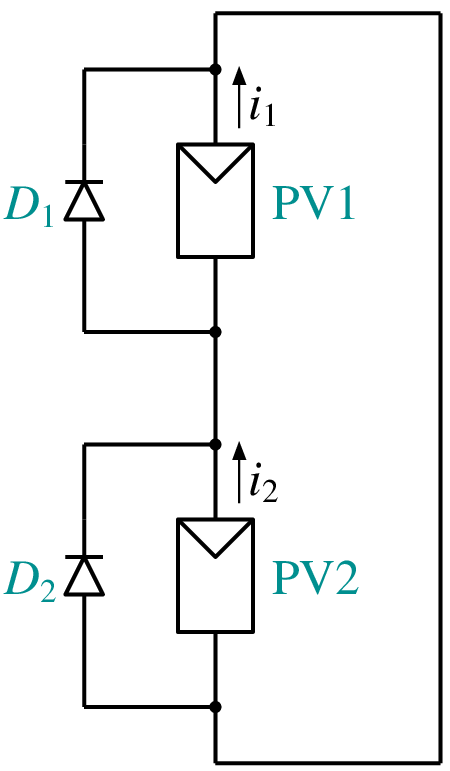

```python
from IPython.display import Image
Image(filename =r'solar_4_fig_1.png', width=140)
```

```python
# run this cell to view the circuit file.
%pycat solar_4_orig.in
```

We now replace the strings such as \$Voc_ref with the values of our choice by running the python script given below. It takes an existing circuit file `solar_4_orig.in` and produces a new circuit file `solar_4.in`, after replacing \$Voc_ref, etc. with values of our choice.

```python
import gseim_calc as calc

s_g_rad_1 = '1000'
s_g_rad_2 = '500'
s_t_C = '25'
s_Nc = '60'
s_Voc_ref = '40.9'
s_Isc_ref = '10.15'
s_Vm_ref = '33.4'
s_Im_ref = '9.59'
s_coef_Isc = '0.058'
s_coef_Voc = '-0.32'

l = [
  ('$g_rad_1', s_g_rad_1),
  ('$g_rad_2', s_g_rad_2),
  ('$t_C', s_t_C),
  ('$Nc', s_Nc),
  ('$Voc_ref', s_Voc_ref),
  ('$Isc_ref', s_Isc_ref),
  ('$Vm_ref', s_Vm_ref),
  ('$Im_ref', s_Im_ref),
  ('$coef_Isc', s_coef_Isc),
  ('$coef_Voc', s_coef_Voc),
]
calc.replace_strings_1("solar_4_orig.in", "solar_4.in", l)
print('solar_4.in is ready for execution')
```

```
solar_4.in is ready for execution
```

**Execute the following cell to run GSEIM on solar_4.in.**

```python
import os
import dos_unix
# uncomment for windows:
#dos_unix.d2u("solar_4.in")
os.system('run_gseim solar_4.in')
```

```
Circuit: filename = solar_4.in
GSEIM: Program completed.
```

```
0
```

The circuit file (`solar_4.in`) is created in the same directory as that used for launching Jupyter notebook. The last step (i.e., running `GSEIM` on `solar_4.in`) creates a data file called `solar_4.dat` in the same directory. We can now use the python code below to compute/plot the various quantities of interest.

```
filename: solar_4.dat
IPV1 at V=0:  10.150 A
IPV2 at V=0:   5.075 A
ID1 at V=0:  -0.000 A
ID2 at V=0:   5.075 A
```

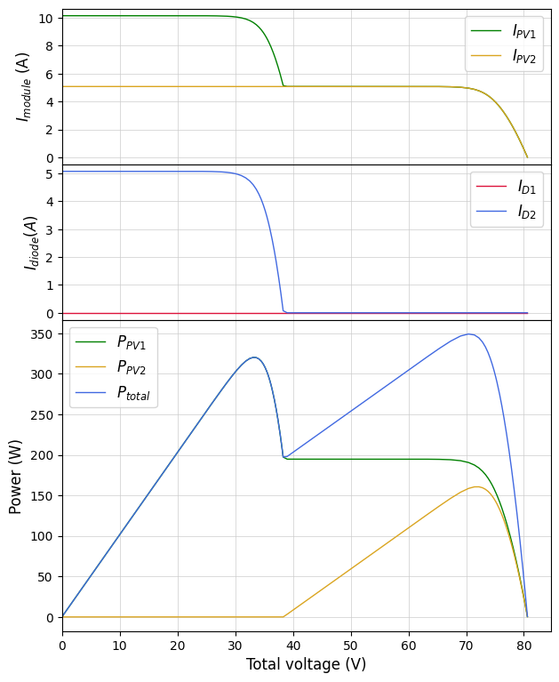

```python
import numpy as np
import matplotlib.pyplot as plt
import gseim_calc as calc
from setsize import set_size

slv = calc.slv("solar_4.in")

i_slv = 0
i_out = 0
filename = slv.l_filename_all[i_slv][i_out]
print('filename:', filename)
u = np.loadtxt(filename)
t = u[:, 0]

i1  = slv.get_array_double(i_slv,i_out,"i1",u)
i2  = slv.get_array_double(i_slv,i_out,"i2",u)
ID1 = slv.get_array_double(i_slv,i_out,"ID1",u)
ID2 = slv.get_array_double(i_slv,i_out,"ID2",u)
p1  = slv.get_array_double(i_slv,i_out,"p1",u)
p2  = slv.get_array_double(i_slv,i_out,"p2",u)
v_p = slv.get_array_double(i_slv,i_out,"v_p",u)

p_total = p1 + p2

v_p = v_p

i1_sc  = i1[0]
i2_sc  = i2[0]
ID1_sc = ID1[0]
ID2_sc = ID2[0]

print('IPV1 at V=0:', "%7.3f"%i1_sc, "A")
print('IPV2 at V=0:', "%7.3f"%i2_sc, "A")
print('ID1 at V=0:', "%7.3f"%ID1_sc, "A")
print('ID2 at V=0:', "%7.3f"%ID2_sc, "A")

color1 = 'green'
color2 = 'crimson'
color3 = 'blue'
color4 = 'royalblue'
color5 = 'goldenrod'
color6 = 'red'

fig, ax = plt.subplots(3, sharex=False, gridspec_kw={'height_ratios': [1, 1, 2]})
plt.subplots_adjust(wspace=0, hspace=0.0)

set_size(5.5, 7, ax[0])

ax[0].plot(v_p, i1 , color=color1, linewidth=1.0, label="$I_{PV1}$")
ax[0].plot(v_p, i2 , color=color5, linewidth=1.0, label="$I_{PV2}$")
ax[1].plot(v_p, ID1, color=color2, linewidth=1.0, label="$I_{D1}$")
ax[1].plot(v_p, ID2, color=color4, linewidth=1.0, label="$I_{D2}$")
ax[2].plot(v_p, p1 , color=color1, linewidth=1.0, label="$P_{PV1}$")
ax[2].plot(v_p, p2 , color=color5, linewidth=1.0, label="$P_{PV2}$")
ax[2].plot(v_p, p_total     , color=color4, linewidth=1.0, label="$P_{total}$")

ax[0].set_ylabel(r'$I_{module}$ (A)', fontsize=12)
ax[1].set_ylabel(r'$I_{diode} (A)$' , fontsize=12)
ax[2].set_ylabel('Power (W)'        , fontsize=12)

for i in range(2):
    ax[i].tick_params(labelbottom=False)

for i in range(3):
    ax[i].grid(color='#CCCCCC', linestyle='solid', linewidth=0.5)
    ax[i].set_xlim(left=0.0)

ax[2].set_xlabel('Total voltage (V)', fontsize=12)

ax[0].legend(loc = 'upper right',frameon = True, fontsize = 10, title = None,
  markerfirst = True, markerscale = 1.0, labelspacing = 0.5, columnspacing = 2.0,
  prop = {'size' : 12},)
ax[1].legend(loc = 'upper right',frameon = True, fontsize = 10, title = None,
  markerfirst = True, markerscale = 1.0, labelspacing = 0.5, columnspacing = 2.0,
  prop = {'size' : 12},)
ax[2].legend(loc = 'upper left',frameon = True, fontsize = 10, title = None,
  markerfirst = True, markerscale = 1.0, labelspacing = 0.5, columnspacing = 2.0,
  prop = {'size' : 12},)

#plt.tight_layout()
plt.show()
```

This notebook was contributed by **Prof. Nakul Narayanan K**, Govt. Engineering College, Thrissur. He may be contacted at nakul@gectcr.ac.in.